# Lab Exercise Sampling 2

Jyotishka Datta

February 1, 2019

## Rules:

1. Email your answers to stat5443.fall@gmail.com.
2. No late submissions.

## Problem 1

- We’ll see that change of variable often helps with difficult sampling problems. Suppose you have a random variable $X$ with the following density function with an unknown normalizing constant:
  $$f(x) = \exp\{-x^6/10\} \; \text{ where } x \in (0, \infty)$$
  How do we sample from this density? Let’s look at a general density of this class with parameters $k$ and $n$:
  $$f(x) \propto \exp\{-k x^{n}\}, \; \text{ where } x \in (0, \infty), k > 0, n > 0.$$
  Show that the transformed variable $Y = X^{n}$ is a Gamma random variable with shape = $1/n$ and rate = $k$, following the steps outlined below:
1. Show that under the transformation $x = y^{1/n}$, the transformed density will be:
   $$f(y) \propto y^{\frac{1}{n}-1} \exp\{-k y\} \; \text{ where } y \in (0, \infty)$$
2. Now, compare the density of $y$ with the Gamma density function with shape parameter $\alpha$ and rate parameter $\lambda$:
   $$f(u) = \frac{\lambda^{\alpha} e^{-\lambda u} u^{\alpha - 1}}{\Gamma(\alpha)}, \; u \ge 0$$
   What are your parameters $\alpha$ and $\lambda$?
3. In R, the function for generating $\text{Gamma}(\alpha, \lambda)$ random samples is `rgamma(n, shape = alpha, rate = lambda)`. Generate $10^5$ samples $Y$ from Gamma distribution with $\lambda = 1/10$ and $\alpha =1/6$. This will give you samples from the distribution of $X$.

Plot the histogram of $X = Y^{\alpha}$ along with the function $\exp\{-x^6/10\}$ to visually verify your sampler. You can use the following code for plotting (your plot should look like the Fig. 1):

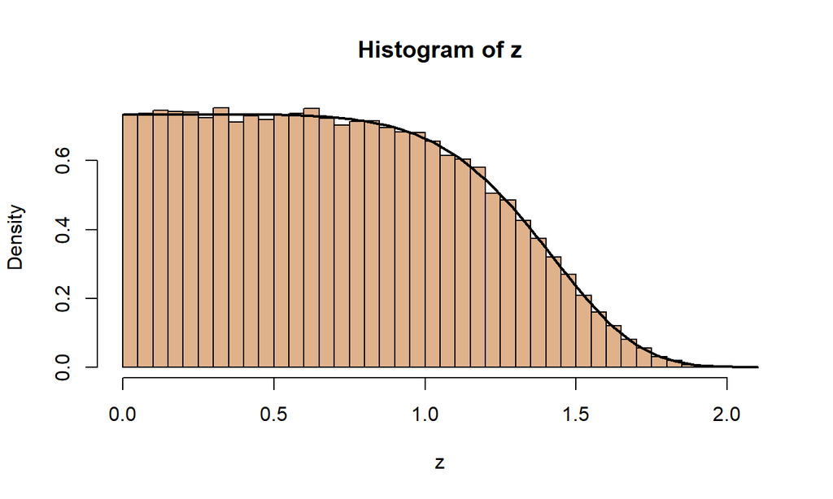

```r
hist(z, breaks = 30, freq = F, col = rgb(0.75,0.4,0.1,0.5)) # z is your sample
lambda = 1/10; alpha = 1/6
target <- function(x){exp(-lambda*x^(1/alpha))/
integrate(function(x) exp(-lambda*x^(1/alpha)),0,Inf)$value}
curve(target,lwd=2,add=T)
```

## Problem 2

Suppose you have a distribution with density:
$$p(x) = \alpha \frac{x_m^{\alpha}}{x^{\alpha+1}} \quad \text{where } x \ge x_m, \; x_m \ge 0, \alpha > 0.$$

1. Write an **one-line function** in `R` based on the inversion method to generate $n=100$ samples from the distribution where $\alpha$ and $x_m$ are the inputs for the function.
2. How would you estimate $\text{Median}(X)$ if $X$ has the distribution described above with $x_m = 1$ and $\alpha = 3$ using your samples from part (1)?

The theoretical median of this distribution is given by:
$$\text{Median}(X) = x_m 2^{1/\alpha}.$$
How close is your estimate?

3. The mean of this distribution is given as follows:
   $$\mathbb{E}(X) = \begin{cases}
   \infty \text{ for } \alpha \le 1 \\
   \frac{x_m \alpha}{(\alpha-1)} \text{ for } \alpha > 1.
   \end{cases}$$
   Calculate the mean for $\alpha = 3$, and report your Monte Carlo mean versus the true mean.
4. The true mean is infinite for $\alpha = 0.75$, what happens to the Monte Carlo mean if you keep increasing the number of sample size $n = 10, \ldots, 1000$ and calculate the Monte Carlo mean for $\alpha = 0.75$ for each $n$?

What pattern do you observe? [You can plot the Monte Carlo mean vs. $n$ for different $\alpha$ and compare, like the one given below.]

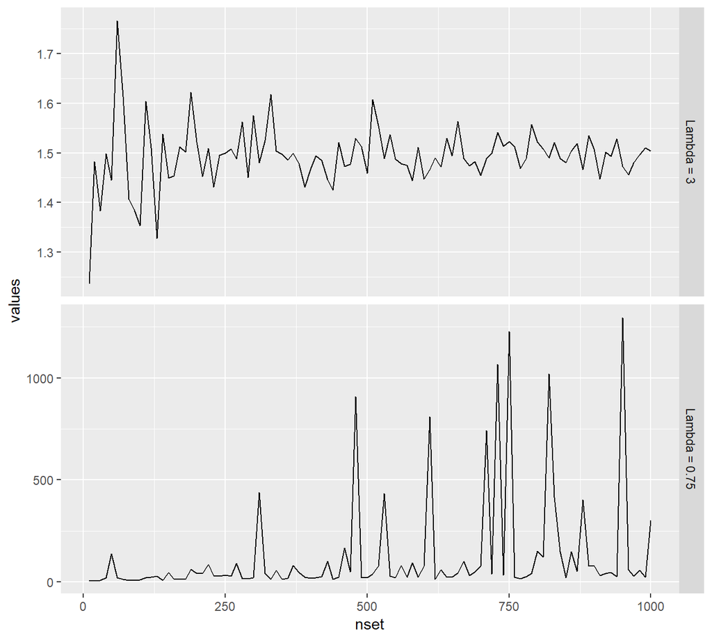

```r
lambda1 = 3
lambda2 = 0.75
nset = 10*{c(1:1e2)} # or any sequence you like

paretomeans.1 = paretomeans.2 = NULL # initialize

for(i in 1:length(nset)){
  n = nset[i]
  ## paretomean(n,x_m,lambda) returns the Monte Carlo mean

  paretomeans.1 = c(paretomeans.1,paretomean(n, x_m = 1, lambda = lambda1))
    paretomeans.2 = c(paretomeans.2,paretomean(n, x_m = 1, lambda = lambda2))
}

pareto.data = rbind(data.frame(values = paretomeans.1,
                               type= "Lambda = 3"),
                    data.frame(values = paretomeans.2,
                               type= "Lambda = 0.75"))
pareto.data = cbind(pareto.data, nset)

library(ggplot2)
ggplot(pareto.data, aes(x = nset, y = values, group = type))+
  geom_line()+facet_grid(type~., scales = "free_y")
```